# S1. TGFbeta Timecourse C1 CAGE Analysis: Main Data Processing

### 4.1.2 Applying the size factors to normalize expression

We can finally compute normalized log-expression values from the count data. Each value is the log-ratio of each count to the size factor for the corresponding cell, with prior.count of 1. The computed values can be retrieved from the SCE object by ‘exprs(sce)’.

```r
sce <- normalize(sce)
```

## 4.2 Checking for Important Technical Factors

Are there any technical factors that are significantly affecting to gene expression variation? These need to be removed to ensure unwanted variances or correlations.

Note that in single cell data, it is often the case that the number of total features becomes a leading distinguishing feature (high correlation with principle component 1 for example). This is something that needs to be accounted for.

While we check for the technical factors, we also compare the results for before/after promoter filtering based on the mean expression level and the number of cells they are expressed in.

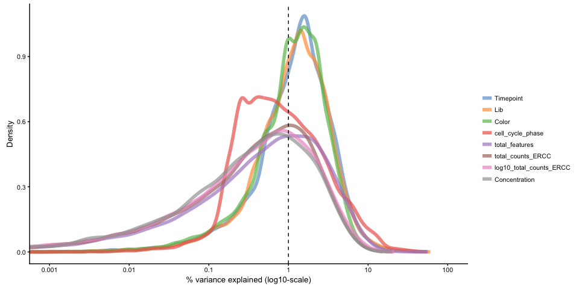

```r
plotExplanatoryVariables(sce, variables=c('total_features',"total_counts_ERCC", "log10_total_counts_ERCC", "Lib", "Concentration", "Timepoint", "Color","cell_cycle_phase")) + fontsize
```

# 5 Identification of HVGs from the normalized log-expression

We need to identify the highly variable genes, then separate the variance into biological and technical components. In theory, the technical component can be calculated by fitting the mean-variance trend to the spike-in transcripts (trendVar), the calculate the biological components by removing this technical component from the total variance (decomposeVar). However, in practice, relying on spikes for this purpose can be unreliable due to a number of reasons (covered in various authors, including Tung et al. 2017). Instead, we can fit the trend to the variance estimates of the endogenous genes (assumption = most of the genes are not variably expressed, such that the technical component dominates), and this trend is used as an estimate of the technical component. Having said that, since we are dealing with differently treated samples, this may not be a safe assumption.

So which one works better?

## 5.1 Mean-Variance Trend Fitting and Identification of Highly Variable Promoters

First, the model design:

```r
# Leave out cell cycle scores, as we are unsure of their reliability
design <- model.matrix(~Lib + Color, data=colData(sce))
```

For the fit without spikes, the assumption is that the cells are mostly homogenous, with little expression differences. However, this is not the case with our data (at least not our expectation), as we have time-series data after TGF-beta induction. So it’s possible that spike-based fit would be better, but let’s try all cases and see how they look.

```r
# all endogenous genes, no spikes, span=0.1
var.fit1 <- trendVar(sce, parametric=TRUE, design=design, use.spikes=FALSE, span=0.1)
var.out1 <- decomposeVar(sce, var.fit1)

# all endogenous genes, no spikes, span=0.2
var.fit2 <- trendVar(sce, parametric=TRUE, design=design, use.spikes=FALSE, span=0.2)
var.out2 <- decomposeVar(sce, var.fit2)

# spikes
var.fit3 <- trendVar(sce, parametric=TRUE, design=design, span=0.2)
var.out3 <- decomposeVar(sce, var.fit3)
```

We will plot the variance of expression vs. the mean expression only for the full set, as the inclusion/exclusion of mitochondrial promoters should not produce noticeable effect.

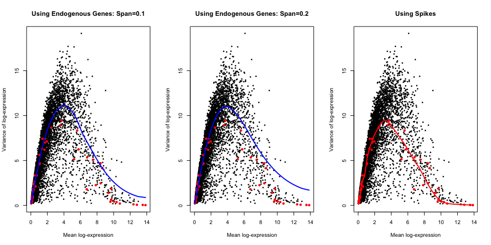

```r
par(mfrow=c(1,3))

plot(var.out1$mean, var.out1$total, pch=16, cex=0.6, xlab="Mean log-expression", ylab="Variance of log-expression", main="Using Endogenous Genes: Span=0.1")
cur.spike <- isSpike(sce)
points(var.out1$mean[cur.spike], var.out1$total[cur.spike], col="red", pch=16)
o <- order(var.out1$mean)
lines(var.out1$mean[o], var.out1$tech[o], col="blue", lwd=2)

plot(var.out2$mean, var.out2$total, pch=16, cex=0.6, xlab="Mean log-expression", ylab="Variance of log-expression", main="Using Endogenous Genes: Span=0.2")
cur.spike <- isSpike(sce)
points(var.out2$mean[cur.spike], var.out1$total[cur.spike], col="red", pch=16)
o <- order(var.out2$mean)
lines(var.out2$mean[o], var.out2$tech[o], col="blue", lwd=2)

plot(var.out3$mean, var.out3$total, pch=16, cex=0.6, xlab="Mean log-expression", ylab="Variance of log-expression", main="Using Spikes")
cur.spike <- isSpike(sce)
points(var.out3$mean[cur.spike], var.out3$total[cur.spike], col="red", pch=16)
o <- order(var.out3$mean)
lines(var.out3$mean[o], var.out3$tech[o], col="red", lwd=2)
```

Trend fitting using spikes results would result in much higher number of high variance genes comapred to the fitting using the endogenous genes. For the endogenous genes, using span of 0.1 results in a better fit for higher expressed genes.

```r
hvg.spikes <- var.out2[which(var.out2$FDR <= 0.05 & var.out2$bio >= mean(var.out2$bio)),] # need to keep this consistent
hvg.spikes <- hvg.spikes[order(hvg.spikes$bio, decreasing=TRUE),]

hvg.nonvar <- var.out3[which(var.out3$FDR <= 0.05 & var.out3$bio >= mean(var.out3$bio)),]
hvg.nonvar <- hvg.nonvar[order(hvg.nonvar$bio, decreasing=TRUE),]
```

We define High Variance Genes as those with biological variation above the 75% quantile and FDR < 0.05.

```r
var.out <- var.out3
var.fit <- var.fit3
hvg.out <- var.out[which(var.out$FDR <= 0.05 & var.out$bio >= quantile(var.out$bio)[4]),]
hvg.out <- hvg.out[order(hvg.out$bio, decreasing=TRUE),]

rm(var.out1, var.fit1, var.out2, var.fit2, var.out3, var.fit3, o)
```

```r
# for convenience, let's add promoter annotation to hvg.out
hvg.out$clusterID <- rownames(hvg.out)
hvg.out <- dplyr::right_join(annot[,c('clusterID','clusterName','type','geneNameStr','geneClassStr','chrom','start','end','strand')], hvg.out, by='clusterID')
```

We now have 1148 promoters identified as highly variable. Of those, 23 are enhancers.

## 5.2 Denoising expression values using PCA

This is a new feature in the updated scran package. We use PCA to remove random technical noise after it has been modeled.

```r
sce <- denoisePCA(sce, technical=var.fit$trend)
dim(reducedDim(sce, "PCA"))
```

```
## [1] 136  18
```

How do the top HVGs look in terms of expression?

```
## 'colour', which will replace the existing scale.
```

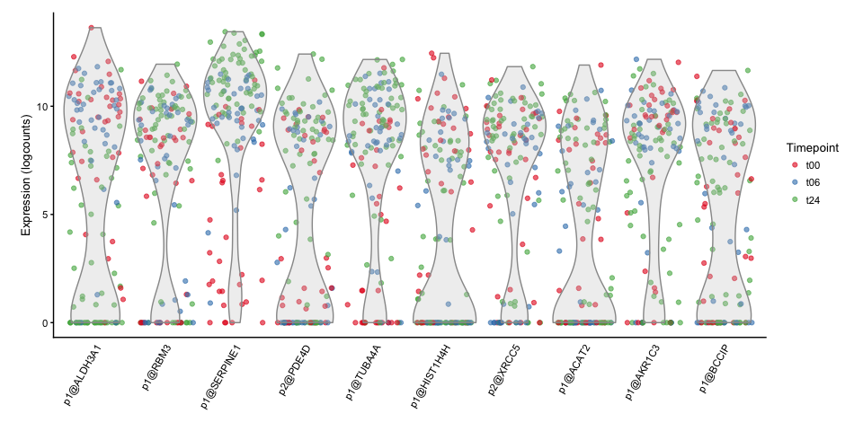

```r
# for convenience, so that you can show clusterNames instead of IDs
sce.plot <- sce
rownames(sce.plot) <- rowData(sce.plot)$clusterName

plotExpression(sce.plot, features=hvg.out$clusterName[1:10], colour_by='Timepoint', jitter="jitter") + scale_color_manual(values=sample.colors$Timepoint[sce$Timepoint])
```

- ‘p1@ALDH3A1’ is strongly down-regulated as part of the TGF-beta response. ALDH3A1 is a known predictor of therapeutic response to chemotherapy in breast cancer patients.
- ‘p1@SERPINE1’ is strongly up-regulated as part of the TGF-beta response. SERPINE1 is an indicator of increased metastasis in human melanoma, and an EMT marker.

## 5.3 Genes defining sub-populations

```r
set.seed(100)
var.cor <- correlatePairs(sce, design=design, subset.row=hvg.out$clusterID)

sig.cor <- var.cor$FDR <= 0.05
summary(sig.cor)
```

```
##    Mode   FALSE    TRUE
## logical  658246     132
```

```r
var.cor <- var.cor[sig.cor,]
```

# 6 Batch Effect Removal

## 6.1 Batch removal in normalized data

The batch removal itself is done using limma::removeBatchEffect function.

Given a time point, Lib and Color are not orthogonal. But their usage are not consistent across the Timepoint.

```r
table(colData(sce)[,c('Lib','Color','Timepoint')])
```

```
## , , Timepoint = t00
##
##         Color
## Lib      G/R Green Red
##   CAGE_4  19     0   0
##   CAGE_5   0     6   0
##   CAGE_6   0     0  10
##
## , , Timepoint = t06
##
##         Color
## Lib      G/R Green Red
##   CAGE_4   0    12   0
##   CAGE_5   0     0   7
##   CAGE_6  19     0   0
##
## , , Timepoint = t24
##
##         Color
## Lib      G/R Green Red
##   CAGE_4   0     0  37
##   CAGE_5  13     0   0
##   CAGE_6   0    13   0
```

Should they both be included as covariates? Or only one? While not shown in this analysis, there are some differences in the batch-removed expression values depending on whether Lib or Color is used as the sole source of batch effects. Let’s include them both, but in an explicit manner using the design matrix.

```r
design <- model.matrix(~Timepoint + Lib + Color, data=colData(sce))
treat.design <- design[,1:3]
batch.design <- design[,-(1:3)]

adj.exprs <- limma::removeBatchEffect(exprs(sce), design=treat.design, covariates=batch.design)

norm_exprs(sce) <- adj.exprs

rownames(adj.exprs) <- rownames(sce.plot)
norm_exprs(sce.plot) <- adj.exprs

rm(adj.exprs, treat.design, batch.design, design)
```

### 6.1.1 PCA of the normalized, batch-corrected data

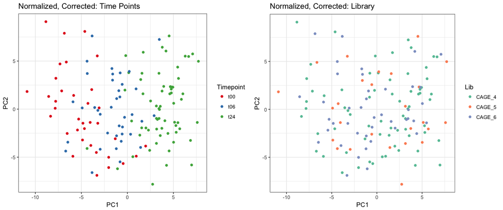

```r
sce <- runPCA(sce, ntop=500, exprs_values='norm_exprs')

tab <- data.frame(reducedDim(sce, 'PCA'), Timepoint=sce$Timepoint, Lib=sce$Lib)
p1 <- ggplot(tab, aes(x=PC1, y=PC2, color=Timepoint)) + geom_point() + fontsize + ggtitle("Normalized, Corrected: Time Points") + scale_color_manual(values=sample.colors$Timepoint[sce$Timepoint]) + theme_bw()
p2 <- ggplot(tab, aes(x=PC1, y=PC2, color=Lib)) + geom_point() + fontsize + ggtitle("Normalized, Corrected: Library") + scale_color_manual(values=sample.colors$Lib[sce$Lib]) + theme_bw()
multiplot(p1, p2, cols=2)
```

```r
# supplementary figure S1
pdf(file.path(dirs$manuscript, "FigS1/batch_corrected_PCA.pdf"), width=12, height=5)
multiplot(p1, p2, cols=2)
dev.off()
```